# Effects of herbivory on leaf life span in woody plants: a meta‐analysis - Zvereva - 2014 - Journal of Ecology - Wiley Online Library

[Journal of Ecology](https://besjournals.onlinelibrary.wiley.com/journal/13652745)

[Volume 102, Issue 4](https://besjournals.onlinelibrary.wiley.com/toc/13652745/2014/102/4) p. 873-881

Special Feature: Meta-Analysis in Plant Ecology – Standard Paper

Free Access

# Effects of herbivory on leaf life span in woody plants: a meta-analysis

[Elena L. Zvereva](https://besjournals.onlinelibrary.wiley.com/authored-by/Zvereva/Elena+L.),

[Mikhail V. Kozlov](https://besjournals.onlinelibrary.wiley.com/authored-by/Kozlov/Mikhail+V.),

First published: 27 March 2014

https://doi.org/10.1111/1365-2745.12252

Citations: 33

## Summary

1. Premature abscission of leaves damaged by herbivores can increase the degree of defoliation beyond that imposed directly by insect feeding. Our aim was to explore the general patterns and sources of variation in the effects of insect herbivory on leaf life span in woody plants.
2. Meta-analysis of published data demonstrated that herbivory significantly reduced the life span of damaged leaves; insect feeding had a greater effect than the same level of herbivory simulated by mechanical wounding. The effects of both natural and simulated herbivory became stronger with increase in the proportion of damaged leaf area. Damage to young leaves and to plant species with higher specific leaf area resulted in a greater reduction in leaf life span than damage to mature leaves and to species with lower specific leaf area.
3. Herbivores differed in the magnitude of their effects on leaf life span, but this variation was not explained by herbivore feeding guilds or specialization.
4. Natural herbivory similarly reduced leaf life span in deciduous and evergreen trees, thereby questioning the hypothesis that premature abscission as a defence response is primarily a characteristic of evergreen trees. However, simulated herbivory imposed stronger effects on evergreens, suggesting that they are more sensitive to non-specific wound-induced elicitors than deciduous trees.
5. *Synthesis*. We demonstrated that, in spite of pronounced variation between study systems, herbivory in general reduces the life span of the damaged leaves of woody plants. Our results suggest that variability in plant responses to herbivory may be linked with the leaf economic spectrum. Premature abscission of damaged leaves can be seen as a tolerance strategy that reduces the negative consequences of local damage on the whole plant. This phenomenon should be accounted for in estimation of losses of net primary production caused by herbivory.

## Introduction

Studies addressing the effects of herbivores on plant communities have generally focused on the removed plant biomass (Cyr & Pace 1993; Schowalter & Lowman 1999). However, in addition to direct consumption of foliar tissues or photosynthates, insect feeding selectively impairs the remaining leaf tissue by altering leaf physiology, including the suppression of photosynthesis (Nabity, Zavala & DeLucia 2009). Some of these changes may lead to premature abscission of damaged leaves, which increases the degree of defoliation beyond that imposed directly by insect feeding (Blundell & Peart 2000). In some ecosystems, the loss of plant material via the premature abscission of insect-damaged leaves is greater, or at least equal, to the leaf biomass consumed by insect herbivores (Burrows 2003; Mazía *et al*. 2012). Therefore, losses from herbivore-induced abscission need to be accounted for to correctly estimate the effects of herbivory on plant communities. Furthermore, premature leaf abscission, by modifying nutrient cycles, may have important consequences for ecosystem functioning (Risley 1993; Hunter 2001).

Although the phenomenon of premature abscission of damaged leaves has been recognized for decades, the number of case studies reporting quantitative data is surprisingly low (see Appendices S1–S2 in Supporting Information). Furthermore, most of the studies tested the hypothesis that damaged leaves abscise earlier than intact leaves, whereas the actual reduction in leaf life span has been measured only rarely. Thus, although the existence of the effect has been demonstrated in a number of studies, its magnitude and potential consequences for plant fitness remain poorly documented. Furthermore, almost half of the data on the effects of herbivory on leaf abscission were obtained from experiments involving mechanically damaged leaves. Plant responses to damage, particularly growth and defensive responses, can greatly differ between natural herbivory and mechanical wounding (Baldwin 1990; Koo & Howe 2009; Zvereva & Kozlov 2012), but the direct comparison of the effects of simulated and natural herbivory on leaf life span has been performed only once (Kozlov & Zvereva 2014). Therefore, the extent to which the impacts of mechanical damage on leaf life span mimic the impacts of natural herbivory is unclear.

Other sources of variation in the effects of herbivory on leaf life span have not been explored either, although several hypotheses have been proposed. In particular, these effects were hypothesized to depend on plant life-history traits (Blundell & Peart 2000; Burrows 2003), with the principal difference existing between evergreen and deciduous species (Bultman & Faeth 1986; Karban & Baldwin 1997). Several case studies demonstrated the importance of the timing of damage (Pritchard & James 1984) and of co-occurring abiotic stressors, for example drought (Abbott *et al*. 1993; Stone & Bacon 1994), as well as the dependence of the effect on the intensity of the damage (Blundell & Peart 2000); however, the generality of these patterns remains unknown.

Another gap in our current knowledge concerns the effects of herbivory on needle/scale abscission in conifers. Several publications that reported premature foliar abscission in gymnosperms either did not provide quantitative data (Silver 1957; Habermann 2000) or did not discriminate between different causes of abscission (Chapman *et al*. 2003). Considering the ecological and economical importance of conifers, this research bias requires urgent attention.

Finally, earlier studies addressing the consequences of natural herbivory for leaf life span usually described the effects of the single herbivore species (or the single feeding guild) and did not compare different herbivore guilds (but see Kozlov & Zvereva 2014). However, several studies demonstrated dissimilar impacts of insects from different feeding guilds on photosynthesis and growth of plants (Welter 1989; Zvereva, Lanta & Kozlov 2010), and therefore, their differential effects on leaf abscission are likely.

The aim of the present work was to explore the general patterns and sources of variation in the effects of leaf damage on leaf life span in woody plants. We used a meta-analysis summarizing the published research findings to test the following hypotheses: (i) both natural and simulated insect herbivory causes premature abscission of damaged leaves, (ii) natural herbivory has stronger effects on leaf life span than simulated herbivory, (iii) the effect of herbivory on leaf life span is stronger in evergreen plants than in deciduous plants, (iv) the effect of herbivory on leaf life span differs among insect feeding guilds, (v) the effect of herbivory on leaf life span depends on plant and leaf traits and the timing of the damage, and (vi) the effect of herbivory on leaf life span depends on the damaged leaf area.

## Materials and methods

### Data collection

To be included in our meta-analysis, a study had to fit the following criteria:

1. Changes in the life span of woody plant leaves were measured at a leaf-specific or plant-specific level in terms of: (i) life span (or the date of abscission) of damaged *vs*. undamaged leaves; (ii) proportions of damaged *vs*. undamaged leaves abscised/retained on a tree by a certain date; or c) difference in herbivore damage between abscised and retained leaves;
2. Localized damage was imposed by either insect feeding (in terms of leaf area removed, mined or transformed to a gall; feeding by sucking insects that did not result in the formation of galls was not considered) or herbivory simulated by mechanical wounding;
3. Damage was imposed to the leaf lamina (i.e. petiole damage was not considered); and
4. Means, variances and sample sizes or numbers (percentages) were reported for damaged and undamaged leaves or could be obtained from the authors, or it was possible to estimate missing data from the test statistics.

We searched for publications that met these criteria in the ISI Web of Science data base and Google Scholar using several keywords (‘abscission’, ‘leaf longevity’, ‘leaf life span’ or ‘shedding’ in combination with ‘herbivor*’, ‘insect’ or ‘damag*’) and further examined the reference lists of the identified papers. The search was completed on 15 October 2012.

### Data selection, response variables and classificatory variables

As a rule, we extracted the means, variances and sample sizes (or numbers/percentages of damaged *vs*. undamaged leaves) from the publications or obtained these data from the authors directly (one study: Mazía *et al*. 2012). For several publications, we approximated the variances of the control and treatment groups using the reported means, sample sizes and test statistics, as described by Zvereva, Lanta & Kozlov (2010). For studies that reported the temporal dynamics of leaf fall (i.e. numbers or proportions of leaves abscised by several sequential dates), we calculated the average date of leaf fall for damaged and intact leaves. The authors of several studies did not provide information on the proportions of leaf tissue removed/damaged by each treatment or herbivore (Appendix S1). For six of these studies, we were able to recover this information from the leaf area and/or the mine size of a certain species.

Herbivores were classified by feeding guild (defoliators, miners and gallers) and by the level of specialization to their host plants (high: feed on plants from one genus; low: feed on plants from two or more genera); these moderator variables were independent from each other (*χ*<sup>2</sup> = 4.13, *df* = 2, *P* = 0.13). The studies that reported effects caused by groups of herbivores (e.g., by all miners or all defoliators) were excluded from the latter analysis. The levels of damage (proportion of damaged leaf area) were divided into three groups: low (<10%), moderate (11–49%) and high (>50%). Plants were classified by life-form (evergreen or deciduous), growth rate (slow, moderate or high), shade tolerance (tolerant, moderate or intolerant), ontogenetic stage (mature, i.e. reproductive age, or young) and by leaf traits (type, size, longevity and specific leaf area, SLA). Leaves were classified as simple and compound and divided into 3 groups by maximum leaf length: small (<7 cm), medium (7–20 cm) and large (>20 cm) and into two groups by SLA: low (<10 mm<sup>2</sup> mg<sup>−1</sup>) and high (>10 mm<sup>2</sup> mg<sup>−1</sup>). Species-specific data on leaf traits were extracted either from original studies or from various publications. However, data for some plant species were unavailable, which resulted in smaller sample sizes in some of analyses. In particular, leaf longevity for deciduous plants is reported only rarely, and therefore, our analysis of this source of variation was conducted for evergreens only.

All plant characteristics used as moderators in our meta-analysis varied among the investigated species of woody plants independently from each other (*P* > 0.05), with the exception of SLA which was lower in evergreen plants than in deciduous plants (*χ*<sup>2</sup> = 11.8, d.f. = 1, *P* = 0.0006). Therefore, we searched for the effect of SLA on leaf life span separately within evergreen and deciduous species.

Hedge's *d*, a measure of effect size (ES), was calculated as the difference between the mean values of (i) leaf life spans or dates of leaf fall of damaged and intact leaves, (ii) the proportions of damaged and intact leaves retained on a plant or abscised or (iii) the levels of damage in leaves collected from a plant and from the ground under the plant, divided by the pooled standard deviation and weighted by the sample size. A negative ES indicated that damaged leaves abscised earlier than intact leaves.

When the results were reported as numbers (or percentages) of intact and damaged leaves abscised by a certain date, and no estimates of variation among trees were provided (or if there was a single tree under study), we calculated the ESs as odd ratios using MetaWin 2.0 (Rosenberg, Adams & Gurevitch 2000) and converted the odds ratios to Hedge's *d* using an Excel spreadsheet (available at www.stat-help.com/spreadsheets.html) based on formulas from Borenstein *et al*. (2009).

The mean ESs were computed and compared using the MetaWin 2.0 program. The herbivory was considered to have a statistically significant effect if the 95% confidence interval (CI) of the mean ES did not include zero. All analyses (both categorical and continuous, i.e. meta-regression) were performed using random effects models, assuming that the studies differed not only by sampling error but also by a random component of the ES. The variation in the ESs within and among the classes of categorical variables was explored by calculating the heterogeneity indices (*Q*<sub>T</sub> and *Q*<sub>B</sub>, respectively) and testing these against the chi-square distribution. The temporal changes in effect size were searched for by calculating Pearson correlation between the ES and the year of publication.

We tested for publication bias using the funnel plot method: in the absence of bias, effect size should not correlate with sample size. The studies for which the ESs have been calculated as odd ratios were excluded from this analysis. We also calculated the Rosenthal's fail-safe numbers (*n*<sub>fs</sub>) to check how robust our conclusions were against the non-published results. Finally, we checked our meta-analysis against the quality criteria coined by Koricheva and Gurevitch (2014).

## Results

### Data base

A total of 145 ESs were calculated from 42 papers (Appendices S1–S2) and from 1 unpublished study (Appendix S3). The magnitude of the reported effects did not change with publication year (*r* = −0.03, *n* = 26 years, *P* = 0.88). Experiments simulating herbivore damage yielded 66 ESs, whereas the remaining 79 ESs reflected effects imposed by insect herbivores, among which 43 ESs were calculated for mining insects. These effects were studied in 47 species of woody plants, among which oaks (*Quercus* spp.) were the best represented (11 species, 21 ESs). Importantly, we did not find any published data on conifers that were suitable for meta-analysis and therefore had to use the results of a specifically arranged field study of Norway spruce and Scots pine (Appendix S3); the remaining 22 evergreen species included in our data base were broadleaved.

### Variations related to methodology and the level of damage

The overall effect of herbivory on leaf life span was negative (*d* = −0.84, CI = −0.96 to −0.71) and highly heterogeneous (*Q*<sub>T</sub> = 290.6, d.f. = 144, *P* < 0.0001). This heterogeneity was not related to the diversity of indices used to measure the effect: we found no differences between studies that compared life span of damaged and intact leaves, percentages of retained/abscised leaves, and differences in herbivory between retained and abscised leaves (*Q*<sub>B</sub> = 5.33, d.f. = 2, *P* = 0.07). Papers reporting leaf-specific and plant-specific levels of damage also did not differ in the magnitude of the effects (*Q*<sub>B</sub> = 2.02, d.f. = 1, *P* = 0.15). All of these studies were therefore combined for subsequent analyses.

The authors of 20 of 42 publications compared between 2 and 7 different treatments (median value = 3) to the same control. However, the random removal of non-independent ESs did not change our estimate of the overall effect of herbivory on leaf life span (*d* = −0.86, CI = −1.00 to −0.73). Similarly, exclusion of data on oaks, which were overrepresented in the data base, did not change the mean ES value (*d* = −0.85, CI = −0.99 to −0.71).

The negative impact of both simulated and natural herbivory varied between low, moderate and high levels of damage (natural herbivory: *Q*<sub>B</sub> = 15.7, d.f. = 2, *P* = 0.0004; simulated herbivory: *Q*<sub>B</sub> = 22.1, d.f. = 2, *P* < 0.0001). Natural herbivory had a stronger effect on leaf life span than simulated herbivory at all levels of damage (Fig. 1). Low (<10%) levels of simulated herbivory did not have a statistically significant effect on leaf life span (Fig. 1).

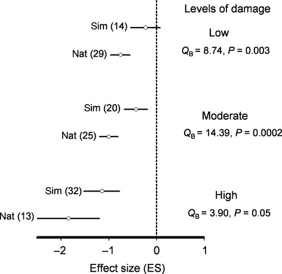

**Figure 1**

Effects (mean Hedges’ *d* effect sizes) of natural (Nat) and simulated (Sim) herbivory on leaf life span of woody plants at three levels of damage (low, <10%; moderate, 11–49%; high, >50% of the leaf area). Horizontal lines denote 95% confidence intervals; sample sizes are shown in brackets. The effect is significant if the 95% confidence interval does not include zero. Significant (*P* < 0.05) *Q*<sub>B</sub> values indicate between-group heterogeneity.

Studies of a single herbivore species yielded greater reduction in leaf life span than studies considering the effects of a multiple-herbivore community (*d* = −1.11, CI = −1.31 to −0.91 and *d* = −0.61, CI = −0.90 to −0.32 respectively, *Q*<sub>B</sub> = 8.42, d.f. = 1, *P* = 0.004).

### Variations related to herbivores

The effects of damage on leaf life span varied among herbivore species (those for which we obtained at least two ESs: *Q*<sub>B</sub> = 39.2, d.f. = 16, *P* = 0.001), but this variation was not explained by herbivore feeding guilds or the level of herbivore specialization (Fig. 2). Galling aphids and gall midges did not differ in their effects on leaf life span (*Q*<sub>B</sub> = 1.05, d.f. = 1, *P* = 0.31).

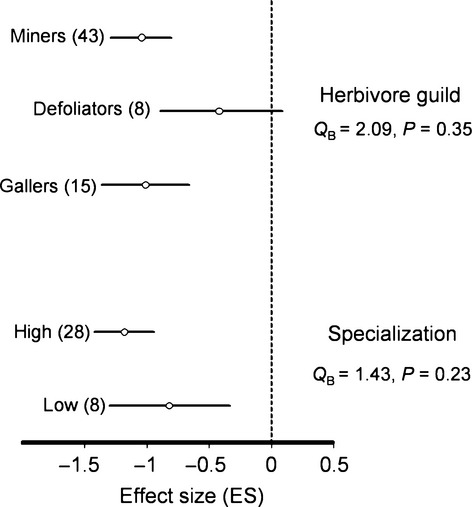

**Figure 2**

Effects (mean Hedges’ *d* effect sizes) of damage by different groups of herbivores on leaf life span of woody plants. For explanations, see Fig. 1.

### Variations related to plants

Herbivory caused a greater decrease in leaf life span in evergreen trees than in deciduous trees (Fig. 3). However, these differences were due to significantly stronger effects of simulated herbivory on evergreens than on deciduous plants, whereas natural herbivory caused similar effects on leaf abscission in evergreen and deciduous trees (Fig. 3). Consequently, in deciduous plants, natural herbivory resulted in a significantly higher reduction in leaf life span than simulated herbivory (*Q*<sub>B</sub> = 8.19, d.f. = 1, *P* = 0.004), whereas in evergreen plants, the effects of natural and simulated herbivory were similar (*Q*<sub>B</sub> = 0.04, d.f. = 1, *P* = 0.85).

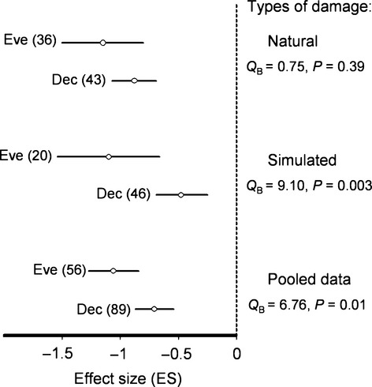

**Figure 3**

Effects (mean Hedges’ *d* effect sizes) of natural and simulated herbivory on leaf life span of evergreen (eve) and deciduous (dec) plants. For explanations, see Fig. 1.

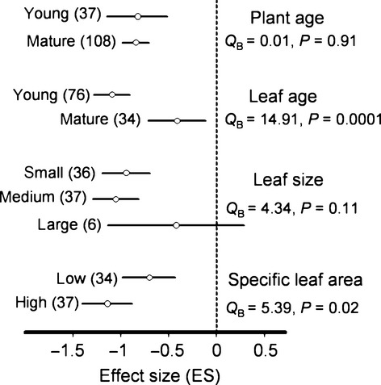

**Figure 4**

Variation in the effects (mean Hedges’ *d* effect sizes) of herbivory on leaf life span of woody plants related to plant characteristics. Variation related to plant and leaf age refers to pooled data including both natural and simulated herbivory, while variation related to leaf size (small, <7 cm; medium, 7–20 cm; large, >20 cm) and specific leaf area (low, <10 mm<sup>2</sup> mg<sup>−1</sup>; high, >10 mm<sup>2</sup> mg<sup>−1</sup>) refers to natural herbivory only. For explanations, see Fig. 1.

## Discussion

### Leaf abscission due to herbivory as a general phenomenon

All woody plants periodically shed their leaves. Abscission is controlled at the level of individual leaves, and the timing of leaf abscission is regulated by a balance between different hormones, with ethylene acting as an accelerator and auxin as inhibitor (Roberts, Elliott & Gonzalez-Carranza 2002). Premature abscission of leaves can be induced by a number of environmental signals, including photoperiod, water stress, invasive stress (including damage by herbivores) and ozone (reviewed by Taylor & Whitelaw 2001).

The effects of herbivory on leaf life span greatly differ among the study systems in both the direction and magnitude. While numerous publications have reported premature abscission of leaves damaged by insects or the experimenter (Williams & Whitham 1986; Simberloff & Stiling 1987; Risley 1993; Gripenberg & Roslin 2008), many researchers found no effects of either natural or simulated herbivory on leaf life span (Heads & Lawton 1983; Kudo 1996; Hodge *et al*. 1998; Wool & Bogen 1999; Hodge, Keesing & Wratten 2000). Some miners were even reported to delay leaf senescence and prevent the host plant from abscising damaged leaves until the completion of larval development (Oishi & Sato 2007). In spite of this variation, our meta-analysis detected strong overall effects of herbivory on leaf life span of woody plants. However, we also found that studies of a single herbivore species yielded stronger effects than studies of multispecies assemblages, suggesting the existence of research bias due to preferential selection of insect species that are known to impose greater damage or stronger effects on plants. This bias, along with publication bias, leads to some overestimation of ecosystem-wide effects of herbivory, but still, premature abscission of damaged leaves can be viewed as one of the general responses of woody plants to herbivory. The generality of this phenomenon emphasizes the importance of studying its ecological and evolutionary consequences.

### Comparison between natural and simulated herbivory

It is commonly appreciated that simulated herbivory cannot recreate the full suite of events that constitute relevant leaf–insect interactions and chemical exchanges. The experiments on downy birch (Kozlov & Zvereva 2014) showed that stronger reduction in leaf life span due to natural herbivory compared to simulated herbivory was not related to the temporal pattern of the damage (gradually accumulating damage or the single damage event). Therefore, the difference in the magnitude of the effect on leaf abscission observed between natural and simulated herbivory is most likely a consequence of other mechanisms.

Many plant defensive responses are elicited only by compounds present in insect oral secretions and thus do not develop following simulated herbivory; as a result, the non-specific response to wounding is likely modified by specific responses to insect-specific elicitors (Kessler & Baldwin 2002). In particular, caterpillar feeding and the application of their oral secretions to wounds, but not wounding alone, induce a burst of ethylene (Kahl *et al*. 2000), which acts as an accelerator of abscission (Roberts, Elliott & Gonzalez-Carranza 2002). Thus, it seems likely that premature abscission in response to damage is considerably enhanced by insect-specific elicitors, at least in deciduous trees (see below). However, although mechanical damage may not faithfully mimic natural damage, simulated herbivory has many advantages (Baldwin 1990) that justify its use in studies of plant responses to herbivory, assuming that the limitations of this method are explicitly appreciated.

The design of studies exploring the consequences of natural herbivory also poses some limitations on the interpretation of results. In these studies, the distribution of damage between trees, shoots and leaves is not random but rather results from selection by herbivorous insects. The single study explicitly addressing this problem demonstrated that the observed effect on leaf life span was directly induced by leaf mining and did not reflect preferential oviposition on leaves programmed for early abscission (Preszler & Price 1993). On the other hand, herbivore species that oviposit late in the season selected for birch trees with later leaf abscission (most likely using the absence of the first signs of senescence as a search cue) to ensure the completion of larval development (Kozlov & Zvereva 2014). The possibility of selective oviposition with respect to the potential life span of the leaf requires detailed investigation and should be taken into account in studies of the effects of natural herbivory. To date, the causality of the effects of damage on the date of leaf abscission is primarily supported by studies employing simulated herbivory.

### Variation in the effects of insect herbivores on leaf life span

The majority of studies on the effects of natural herbivory on leaf life span have been conducted with leaf miners: these insects account for 65% of the guild-specific data in our meta-analysis, compared with 12% on defoliators. This preferential exploration of the effects of miners on leaf abscission can be classified as a research bias because in natural ecosystems, the average background damage imposed by defoliators is more than 10 times as high as the damage caused by miners (Nuckols & Connor 1995; Paul *et al*. 2012). In our opinion, this bias can be explained in two ways. First, leaf mines can usually be attributed to a certain species, in contrast to the damage imposed by defoliators. Secondly, the fates of individual larvae can be inferred from examination of their mines, allowing interpretation of results in terms of plant defence acting through abscission of mined leaves (Owen 1978; Faeth, Connor & Simberloff 1981).

Based on the meta-analysis, we can conclude, for the first time, that insect herbivores from three feeding guilds (miners, defoliators and gallers) do not differ in their effects on leaf life span. However, this conclusion may be biased by the low number of studies on defoliators. On the other hand, galling aphids with piercing mouthparts and gall midges, whose larvae have chewing mouthparts and feed on a nutritive tissue that internally surrounds the gall chamber, impose similar effects on leaf life span, although sap-feeders considerably differ from other feeding guilds in the mechanisms of their effects on plants (as discussed by Zvereva, Lanta and Kozlov 2010). Considering the importance of defoliators and sap-feeders for ecosystem functioning, the collection of additional data on their effects on leaf abscission is an urgent task.

Although specialist and generalist herbivores may differentially influence some plant characteristics (Zvereva, Lanta & Kozlov 2010; Ali & Agrawal 2012), the effects on leaf life span were not related to the level of host plant specialization of individual herbivores. The variation among herbivore species detected in our meta-analysis is more likely explained by the proportion of damaged leaf area (varying from 1.5 to 87.5% in different study systems) and/or the timing of damage (see below) than by the mode of feeding. However, in the analysis of the data on birch-feeding herbivores, accounting for both the timing and intensity of damage, the effect of herbivore species on the date of leaf abscission remained significant, suggesting that specific elicitors of individual herbivores may differ in their effects on leaf life span (Kozlov & Zvereva 2014).

### Intensity and timing of damage

The effects of herbivory on leaf life span were repeatedly demonstrated to increase with the proportion of damaged leaf area (reviewed by Blundell & Peart 2000), and our meta-analysis also detected a decrease in leaf life span with increasing damage intensity. However, in birch, this relationship was observed only when the damage exceeded 15% of the area of the damaged leaf for natural herbivory and 30% for simulated herbivory (Kozlov & Zvereva 2014). Several earlier studies also revealed the existence of thresholds, demonstrating that for miners, it generally lies between 10 and 20% (Hileman & Lieto 1981; Pritchard & James 1984) but can be as low as 3% (Naruse 1978). For simulated herbivory, the threshold falls between 60 and 80% of leaf area (Lam & Dudgeon 1985; Risley 1993). This difference between the effects of natural and simulated herbivory on leaf life span is in line with the generally stronger effect of insect feeding relative to mechanical damage (discussed above).

Young and mature leaves are differentially damaged by a number of herbivore species (Aide & Zimmerman 1990) and may differ in their responses to herbivory (Ohnmeiss & Baldwin 2000; Chen & Poland 2009). Direct comparisons demonstrated that similar levels of mechanical damage were more likely to cause premature abscission of younger leaves than older leaves (Preszler & Price 1993; Risley 1993; Blundell & Peart 2000; Kostenyuk & Burns 2004; Kozlov & Zvereva 2014). However, we are aware of only two studies comparing abscission of differently aged leaves in response to natural damage (Abbott *et al*. 1993; Kozlov & Zvereva 2014). Our meta-analysis confirmed the generality of the conclusions of these two case studies and indicated that insects attacking host plants early in the season reduce leaf life span to a greater extent than species that begin damaging leaves later in the season. Moreover, herbivores that start feeding in late summer do not influence the date of leaf abscission in birch at all (Kozlov & Zvereva 2014).

The detected pattern may result from one or more mechanisms that likely differ between study systems. Abscission of immature leaves is inevitable if the damage removes differentiating cells required for their development (Coleman & Leonard 1995). In addition, growing tissues are most sensitive to environmental stress (Heckenberger, Roggatz & Schurr 1998). In particular, damage imposed by both natural and simulated herbivory causes considerable water loss (Aldea *et al*. 2005), thus leading to water stress, which may differentially affect young and mature leaves (Cechin *et al*. 2006). Moreover, immature leaves also lack lignin, an important defence against pathogens, and thus are vulnerable to infections invading through wounds, which may cause premature abscission (Taylor & Whitelaw 2001). The responses of young and mature leaves to herbivory may differ in terms of damage-induced production of ethylene, which stimulates leaf abscission: for example, aphids feeding on *Dendranthema grandiflora* caused greater ethylene production in young leaves than in mature leaves (Davies *et al*. 2004). Finally, the higher sensitivity of growing leaves to herbivore damage may result from differences in the balance of hormones between growing and mature leaves. Accumulation of auxin in meristems of developing leaves may deplete the surrounding cells of auxin (Heisler *et al*. 2005), thus making the abscission zone more reactive to ethylene induced by leaf damage (Kahl *et al*. 2000; Taylor & Whitelaw 2001). Alternatively, the ability of auxin to promote ethylene synthesis (Taylor & Whitelaw 2001) may accelerate the abscission of young leaves with high auxin activity.

### Plant traits

Based on studies of leaf miners, Bultman & Faeth (1986) suggested that the likelihood of premature abscission due to herbivory is higher for evergreens than for deciduous trees. In spite of weak empirical support (four studies of evergreen plants and a single study of a deciduous tree), this conclusion has served as the basis for further generalizations. Karban and Baldwin (1997) emphasized the differences in mechanisms of induced resistance as the most important distinction between deciduous trees and evergreens, concluding that premature leaf abscission is one of the main defensive responses to herbivory in evergreen plants, whereas in deciduous plants, herbivory commonly results in the induction of secondary compounds but not in premature leaf abscission. However, our meta-analysis does not support this conclusion because the effects of natural herbivory on leaf life span appeared to be similar in a comparison of data from 24 evergreen and 23 deciduous plant species.

On the other hand, simulated herbivory had a significantly greater effect on evergreens. Consequently, the responses of deciduous plants to natural herbivory were much stronger than their responses to simulated herbivory, whereas in evergreens, the responses to these two types of damage were similarly high. This difference in relative sensitivity to herbivore feeding and mechanical damage may indicate that evergreens are more responsive to non-specific wound-induced elicitors, whereas in deciduous plants, herbivore-specific elicitors are more likely to enhance the response to mechanical wounding. Consequently, studies simulating herbivory by mechanical damage (which comprise 51% of the data on deciduous plants) significantly underestimate the effects of herbivory on leaf life span in deciduous plants, thus creating a false impression of their principal difference from evergreen plants. We conclude that premature leaf abscission cannot be viewed as a response to herbivory that is primarily characteristic of evergreen trees.

The reduction in leaf life span in woody plants in response to herbivory depends considerably on species-specific leaf traits. Plants with compound leaves and with large leaves showed weaker responses, which may be explained at least partly by the generally lower proportion of leaf biomass lost due to insect feeding. The effect of damage on leaf life span weakens with the increase in leaf longevity in evergreens and with the decrease in SLA in both evergreen and deciduous plants, indicating that plants with long-living and thicker leaves are less susceptible to damage in terms of reduction in leaf life span. Both leaf longevity and SLA belong to a suite of leaf traits that form the leaf economic spectrum (Wright *et al*. 2004) and are positively correlated with mass-based leaf nitrogen, net photosynthetic capacity and a number of other leaf traits (Reich *et al*. 1999). Therefore, our results may indicate that species with a quicker return on investment in nutrients and dry mass in leaves (i.e. species with higher nutrient concentrations, higher rates of photosynthesis and respiration, shorter leaf longevity and lower dry-mass investment per leaf area) are, in general, more susceptible to herbivore damage and the life span of their leaves is reduced to a greater extent than in plants from the opposite end of the leaf economic spectrum.

### Adaptive significance of premature leaf abscission in response to herbivory

The adaptive significance of early abscission of damaged leaves has been widely discussed, in particular as a mechanism of the induced plant defence against insect attack (e.g. Owen 1978; Faeth, Connor & Simberloff 1981; Williams & Whitham 1986; Waddell *et al*. 2001). However, premature abscission of damaged leaves can cause mortality of herbivores only when (i) the development of a herbivore is restricted to a single leaf (as in mining and galling insects), (ii) the damaged leaf sheds before the herbivore completes its development, or (iii) the herbivore's development cannot be continued in a shed leaf, or the risk of predation is higher in shed leaves. This combination rarely occurs in nature; consequently, the effect of early leaf shedding on insect mortality has been found in only a few studies (Faeth, Connor & Simberloff 1981; Williams & Whitham 1986; Simberloff & Stiling 1987; Mopper & Simberloff 1995), and its generality has been repeatedly questioned (Kahn & Cornell 1983; Stiling & Simberloff 1989; Preszler & Price 1993).

Although some responses, such as premature abscission of intact leaves situated next to the damaged leaves (Stiling, Simberloff & Brodbeck 1991; Kozlov & Zvereva 2014), can hardly be seen as adaptive, abscising leaves damaged by herbivores may still benefit plants for a number of reasons. First, wounding can provide entry points for pathogens; therefore, it is to the plant's distinct advantage to drop the damaged leaf to prevent further invasion and spread of infection (Taylor & Whitelaw 2001). Secondly, herbivory enhances water loss from cut edges, thus leading to leaf dehydration (Aldea *et al*. 2005); shedding of these leaves allows the maintenance of a favourable water balance of the whole plant (Munné-Bosch & Alegre 2004). In addition, water deficits initiate signalling related to senescence (Lim, Kim & Nam 2007), which is generally accompanied by export of nutrients from senescent leaves to young growing tissues or storage organs so that nutrient utilization is optimized at the whole plant level (Munné-Bosch & Alegre 2004).

Thus, premature leaf abscission in response to herbivore damage can only rarely be classified as an induced resistance strategy. In general, it is a tolerance strategy that reduces the negative consequences of local damage on the whole plant.

## Conclusions

Testing of the research hypotheses stated in the introduction led to the following conclusions: (i) both natural and simulated insect herbivory cause premature abscission of damaged leaves, (ii) natural herbivory has stronger effects on leaf life span than simulated herbivory, (iii) natural herbivory similarly reduces leaf life span in deciduous and evergreen plants, but simulated herbivory imposes stronger effects on evergreens, (iv) herbivore feeding guilds do not differ in the magnitude of their effects on leaf life span, (v) the effect of herbivory on leaf life span depends on plant and leaf traits and the timing of the damage, and (vi) the effect of herbivory on leaf life span increases with the damaged leaf area.

## Acknowledgements

We are grateful to Dr. C. N. Mazía, Dr. J. Yukawa and Prof. D. Wool for providing additional information, to V. Zverev for assistance in the field experiment, to J. Koricheva for methodological advices and to two anonymous referees for their helpful and inspiring comments. The study was supported by the Academy of Finland (project no. 122133) and a Turku University strategic research grant.

## Citing Literature

[figure not shown]

[Volume102, Issue4](https://besjournals.onlinelibrary.wiley.com/toc/13652745/2014/102/4)

July 2014

Pages 873-881

[figure not shown]